# Introduction

# Installation

GENEMABR can be installed from Bioconductor:

```r
if (!requireNamespace("BiocManager", quietly=TRUE)){
    install.packages("BiocManager")}
BiocManager::install("GENEMABR")
```

The package can be loaded using the `library` command.

```r
library(GENEMABR)

## load other required libraries
library(glmnet)
library(Matrix)
library(igraph)
```

# Gene module annotation or gene set enrichment analysis via regression based method

To test a our method, we use a IgAN-associated module from the paper: Choobdar,S. et al. (2019) Open Community Challenge Reveals Molecular Network Modules with Key Roles in Diseases. bioRxiv, 265553.

IgAN-associated module identified using the consensus analysis in the InWeb protein-protein interaction network. The module comprises immune-related NF-κB signaling pathways.

Figure below shows mannually extracted P-values for some important pathways from GO Ontology and REACTOME database by using the non-central hypergeometric distribution test.

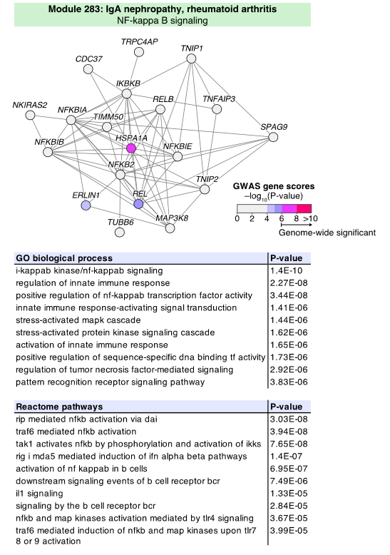

Read non-central hypergeometric distribution test results from original paper for gene module based on GO Ontology and REACTOME pathways

```r
hypergeometric_test_results=read.csv(file = "../inst/extdata/Daniel_S5_mod283.txt",header = T,sep = "\t")
## filterd results with only P.noncentral value less then 0.05
hypergeometric_test_results_filtered=hypergeometric_test_results[hypergeometric_test_results$P.noncentral<0.05,]

dim(hypergeometric_test_results_filtered)
```

```
## [1] 176  11
```

We found traditional non-central hypergeometric distribution test/fisher extact test usually return too much over-presented pathways for certain gene module.

And many of these pathways are highly related. For example,four pathways with pvalues less than 0.05:

immune response-activating cell surface receptor signaling pathway GO:0002429;

immune response-activating signal transduction GO:0002757 ;

immune response-regulating cell surface receptor signaling pathway GO:0002768;

immune response-regulating signaling pathway: GO:0002764.

[GO:0002757 and GO:0002768 are parents of GO:0002429 and GO:0002764 is parents of GO:0002757 and GO:0002768](https://www.ebi.ac.uk/QuickGO/term/GO:0002429)

To get a more sparse results by exploting corraltion between different pathways, we could use “regression_selected_pathways” function in GENEMABR package.

This function use regularised regression methods to do enrichment analysis, such as lasso (l1 regularization), ridge (l2 regularization), or elastic net (hybrid of l1 and l2 regularization controlled by the hyperparameter alpha), in order to adjust the treatment of similar or redundant gene-sets. If two gene-sets are highly redundant, lasso will assign a higher coefficient to one of them randomly, ridge will assign equal coefficients to both of them, whereas elastic net will behave between lasso and ridge.

To use this method, use need to provide a binary gene pathways realationships matrix whose columns are the pathways/gene sets and whose rows are all the genes from pathways/gene sets.For gene i and pathway j, the value of matrix(i,j) is 1 is gene i belonging to pathway j otherwise 0.

Users could use default gene_pathway_matrix(“default”) so it will use pre-collected gene_pathway_matrix from GO Ontology and REACTOME databaase.Altertatively, they could use their own customized gene_pathway_matrix

```r
gene_list=c("TRPC4AP","CDC37","TNIP1","IKBKB","NKIRAS2","NFKBIA","TIMM50","RELB","TNFAIP3","NFKBIB","HSPA1A","NFKBIE","SPAG9","NFKB2","ERLIN1","REL","TNIP2","TUBB6","MAP3K8")
help("regression_selected_pathways")

#Here use regression_selected_pathways with default gene pathway matrix and set the alpha value as 0.5
enrichment_results=regression_selected_pathways(gene_input=gene_list,gene_pathway_matrix="default",alpha=0.5)
enrichment_results
```

```
## $selected_pathways_names
## $selected_pathways_names$`R-HSA-1810476`
## [1] "RIP-mediated NFkB activation via ZBP1"
##
## $selected_pathways_names$`R-HSA-5603029`
## [1] "IkBA variant leads to EDA-ID"
##
## $selected_pathways_names$`GO:0032688`
## [1] "negative regulation of interferon-beta production"
##
## $selected_pathways_names$`R-HSA-933542`
## [1] "TRAF6 mediated NF-kB activation"
##
## $selected_pathways_names$`GO:0007249`
## [1] "I-kappaB kinase/NF-kappaB signaling"
##
## $selected_pathways_names$`R-HSA-1606322`
## [1] "ZBP1(DAI) mediated induction of type I IFNs"
##
##
## $selected_pathways_coef
## R-HSA-1810476 R-HSA-5603029    GO:0032688  R-HSA-933542    GO:0007249
##    0.12593491    0.07105989    0.01993546    0.01910265    0.00513055
## R-HSA-1606322
##    0.00219621
##
## $selected_pathways_fisher_pvalue
## R-HSA-1810476 R-HSA-5603029    GO:0032688  R-HSA-933542    GO:0007249
##  3.511133e-10  4.005332e-08  6.338554e-05  1.929685e-09  4.985802e-11
## R-HSA-1606322
##  7.596824e-10
##
## $selected_pathways_num_genes
## R-HSA-1810476 R-HSA-5603029    GO:0032688  R-HSA-933542    GO:0007249
##            11             7            11            16            63
## R-HSA-1606322
##            13
```

From results above, we can find our methods give a much more sparse while biological meaning results.It captures most important NF-kappaB signaling pathways from the gene module

# Other functions in this methods

```r
## if you use the default pathway databases(GO Ontologyand REACTOME).
## After you extracted enriched pathways, you can use find_root_ids function to find thier GO sub-root or REACTOME roots(ID) to help you better understanding the biological meanings of pathways.
## Here we use GO sub-root instead of GO root nodes as there are only three roots in the GO ontology and it's not so specific
GO_Reactome_root_id=find_root_ids(selected_pathways=names(enrichment_results$selected_pathways_coef))
GO_Reactome_root_id
```

```
## $`R-HSA-1810476`
## [1] "R-HSA-168256"
##
## $`R-HSA-5603029`
## [1] "R-HSA-1643685"
##
## $`GO:0032688`
## [1] "GO:0065007"
##
## $`R-HSA-933542`
## [1] "R-HSA-168256"
##
## $`GO:0007249`
## [1] "GO:0009987#GO:0065007"
##
## $`R-HSA-1606322`
## [1] "R-HSA-168256"
```

```r
# Or if you want to obatain root notes names instead of ID, you can use function from_id2name to get names from ids
GO_Reactome_root_id_names=from_id2name(GO_Reactome_root_id)
GO_Reactome_root_id_names
```

```
## $`R-HSA-168256`
## [1] "Immune System"
##
## $`R-HSA-1643685`
## [1] "Disease"
##
## $`GO:0065007`
## [1] "biological regulation"
##
## $`R-HSA-168256`
## [1] "Immune System"
##
## $`GO:0009987#GO:0065007`
## [1] "cellular process"      "biological regulation"
##
## $`R-HSA-168256`
## [1] "Immune System"
```

```r
# Or you  can use function get_steps function to calculate the distance from selected pathways to GO or Reactome roots
step2root=get_steps(selected_pathways=names(enrichment_results$selected_pathways_coef))
step2root
```

```
## $`R-HSA-1810476`
## [1] 4
##
## $`R-HSA-5603029`
## [1] 3
##
## $`GO:0032688`
## [1] 7
##
## $`R-HSA-933542`
## [1] 3
##
## $`GO:0007249`
## [1] 4
##
## $`R-HSA-1606322`
## [1] 3
```

```r
# To view specic position of GO/REACOTEM pathways in ontology trees.
# You can use Visualization tool at https://www.ebi.ac.uk/QuickGO/ and https://reactome.org/PathwayBrowser/
```